# Microsoft O365 bayesAB Example 1

# Get Experimental Data

Design an experiment to assess the click-through-rate (CTR) onto a page. Randomly show users one of two possible pages (page A or page B). Goal - determine which page, if any, has a higher CTR.

Use `rbinom` to randomly generate two Bernoulli distributions providing each page with a different probability of success.

Plot the CTR for pages A and B to visually compare.

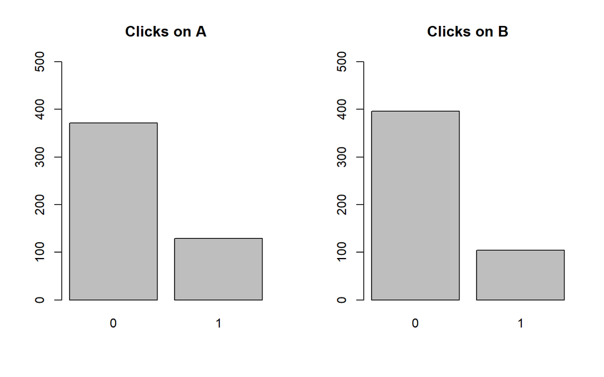

```r
set.seed(14641)
A_binom <- rbinom(500, 1, .25)
B_binom <- rbinom(500, 1, .2)

{par(mfrow=c(1,2))

barplot(table(A_binom), main = "Clicks on A", ylim = c(0, 500))
barplot(table(B_binom), main = "Clicks on B", ylim = c(0, 500))
}
```

Page A appears to have a higher CTR. Perhaps the new page made things worse? Calculate the summary statistics.

```r
summary(A_binom)
```

```
##    Min. 1st Qu.  Median    Mean 3rd Qu.    Max.
##   0.000   0.000   0.000   0.258   1.000   1.000
```

```r
summary(B_binom)
```

```
##    Min. 1st Qu.  Median    Mean 3rd Qu.    Max.
##   0.000   0.000   0.000   0.208   0.000   1.000
```

The mean Page A > mean Page B.

# Why Bayes?

Most A/B test approaches are centered around frequentist hypothesis tests used to calculate a point estimate (probability of rejecting the null) of a hard-to-interpret value. Oftentimes, the statistician or data scientist will have to do a power test to determine sample size and then interface with a Product Manager or Marketing Exec in order to relay the results. This quickly gets messy in terms of interpretability. More importantly it is simply not as robust as A/B testing given informative priors.

The most important reason to prefer Bayesian methods for A/B testing is interpretability: Would you rather say “P(A > B) is 10%”, or “Assuming the null hypothesis that A and B are equal is true, the probability that we would see a result this extreme in A vs B is equal to 3%”?

Also, by using an informative prior we alleviate many common issues in regular A/B testing. For example, repeated testing is an issue in A/B tests. This is when you repeatedly calculate the hypothesis test results as the data comes in. In a perfect world, if you were trying to run a Frequentist hypothesis test in the most correct manner, you would use a power test calculation to determine sample size and then not peek at your data until you hit the amount of data required. Each time you run a hypothesis test calculation, you incur a probability of false positive. Doing this repeatedly makes the possibility of any single one of those ‘peeks’ being a false positive extremely likely. Using an informative prior in Bayesian techniques means your posterior distribution should make sense any time you wish to look at it.

# bayesAB Workflow

- Select a distribution (Bernoulli for CTR)
- Determine prior distribution parameters for your data
- Fit a `bayesTest` object

## Parameterize Data

Based on prior knowledge it is known that page A had a CTR of 25%. There is data to support this so we’re pretty sure about the selection of our prior as being a Bernoulli distribution with the parameter of CTR to lie between .2-.3 range, thus covering the .25.

In this example imagine a change in the font is thest variation to be tested.

### Decide on prior

> The conjugate prior for the Bernoulli distribution is the β distribution.

*You really do not need to worry about this note. It is here for the statistically-minded.*

There are two ways to determine the values for prior. `bayesAB` provides a function for you to experiment to determine the required inputs. Alternatively, the `bayesAB` priors can be derived from the mean and standard distribution. (I like the 2nd method - it saves time.)

#### Derived bayesAB Priors

Using the function below provides the α and β inputs into the `bayesAB` function. Using the information from above, we know the mean conversion rate is 25% and the standard deviation is 5%. (Recall variance = stdDev^2)

```r
Beta_Parameters <- function(mean, variance) {
  alpha <- ((1 - mean) / variance - 1 / mean) * mean ^ 2
  beta <- alpha * (1 / mean - 1)
  return(Beta_Parameters = list(alpha = alpha, beta = beta))
}
```

```r
mu <- .25
var <-  .05^2
Beta_Parameters(mu, var)
```

```
## $alpha
## [1] 18.5
##
## $beta
## [1] 55.5
```

Using these inputs, the foloowing distribution is calculated.

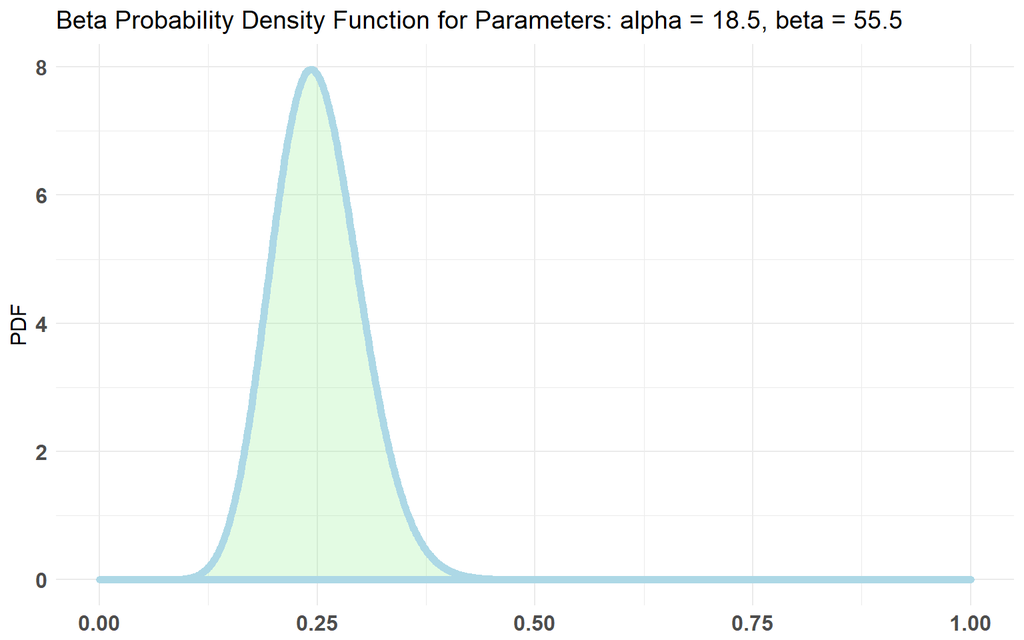

```r
plotBeta(18.5, 55.5)
```

> Recommend using the derived approach when the mean and standard devistion are estimated with some confidence.

#### Experiment with bayesAB

Vary the values of the `plotβ` function to simulate the current performance of the metric sought to evaluate. As an example, assume a conversion rate on a webpage is around 20% and a standard deviation of 4%. Attempt to use different values (`α`, `β`) in `plotβ` to mimic this prior or historical information.

Distributions start to look like a normal distribution as the value of α and β starts to get bigger. Notice with the greater values of α and β, the bell curves are getting thinner or have smaller standard deviations. α tends to represent the mean and moves the curve left (low values) or right. β tends to suggest the standard deviation and makes the curve fatter (low values) or slimmer. **You must eperiment to find a close fit!**

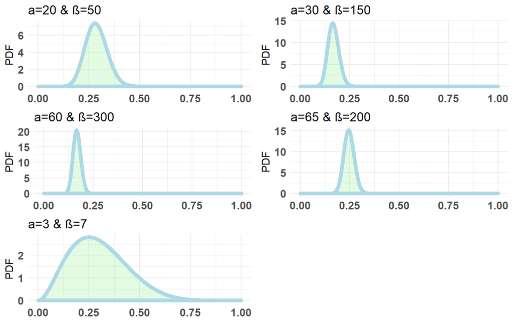

```r
p1 <- plotBeta(20, 50) + ggtitle("α=20 & β=50")
p2 <- plotBeta(30, 150) + ggtitle("α=30 & β=150")
p3 <- plotBeta(60, 300) + ggtitle("α=60 & β=300")
p4 <- plotBeta(65, 200) + ggtitle("α=65 & β=200")
p5 <- plotBeta(3,7) + ggtitle("α=3 & β=7")
grid.arrange(p1, p2, p3, p4, p5, ncol=2)
```

## bayesAB Test

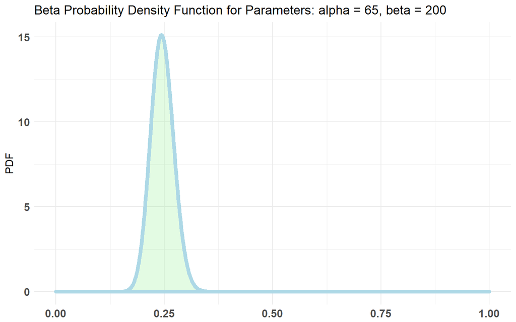

```r
plotBeta(65, 200)
```

All the information is availble for analysis.

```r
ab1 <- bayesTest(A_binom, B_binom, priors = c(alpha = 65, beta = 200), n_samples = 1000, distribution = 'bernoulli')
```

`bayesAB` fits a Bayesian model to the A/B testing sample data. `bayesTest` also comes with generic methods; `print`, `summary` and `plot`.

`print` lists the inputs to the test:

```r
print(ab1)
```

```
## --------------------------------------------
## Distribution used: bernoulli
## --------------------------------------------
## Using data with the following properties:
##             A     B
## Min.    0.000 0.000
## 1st Qu. 0.000 0.000
## Median  0.000 0.000
## Mean    0.258 0.208
## 3rd Qu. 1.000 0.000
## Max.    1.000 1.000
## --------------------------------------------
## Conjugate Prior Distribution: Beta
## Conjugate Prior Parameters:
## $alpha
## [1] 65
##
## $beta
## [1] 200
##
## --------------------------------------------
## Calculated posteriors for the following parameters:
## Probability
## --------------------------------------------
## Monte Carlo samples generated per posterior:
## [1] 1000
```

`summary` provides actionable data. Bayesian intervals treat their bounds as fixed and the estimated parameter as a random variable, whereas frequentist confidence intervals treat their bounds as random variables and the parameter as a fixed value.

The credible interval is more intuitive to both the scientist and the non-scientist. For example, in the experiment it is fairly certain the use of the alterntive font in Page B has had a negative effect on CTR.

- This is quantified - it is 93.8% certain that page A is better than page B.
- The Credible Interval on (A - B) / B suggests Page A as high as .33 times better relative to Page B.

```r
summary(ab1)
```

```
## Quantiles of posteriors for A and B:
##
## $Probability
## $Probability$A
##        0%       25%       50%       75%      100%
## 0.1990660 0.2432687 0.2534296 0.2636561 0.2999087
##
## $Probability$B
##        0%       25%       50%       75%      100%
## 0.1759399 0.2109886 0.2206506 0.2310312 0.2722207
##
##
## --------------------------------------------
##
## P(A > B) by (0)%:
##
## $Probability
## [1] 0.938
##
## --------------------------------------------
##
## Credible Interval on (A - B) / B for interval length(s) (0.9) :
##
## $Probability
##          5%         95%
## -0.01026539  0.32550258
##
## --------------------------------------------
##
## Posterior Expected Loss for choosing B over A:
##
## $Probability
## [1] 0.002784858
```

`plot` plots the priors, posteriors, and the Monte Carlo samples.

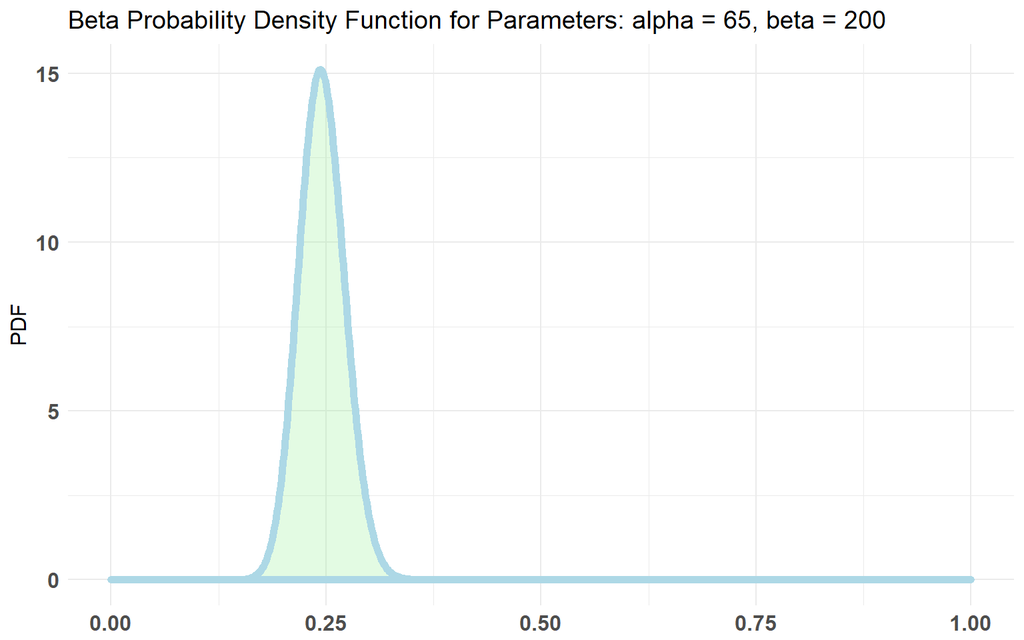

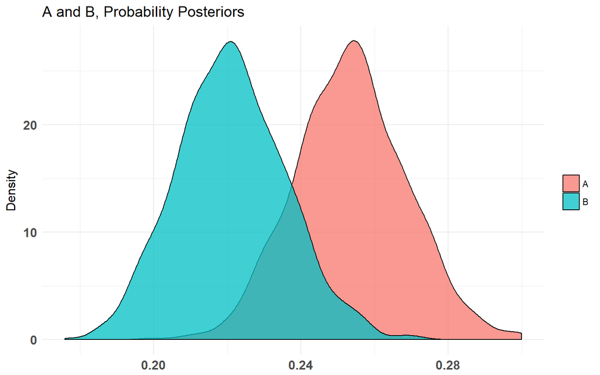

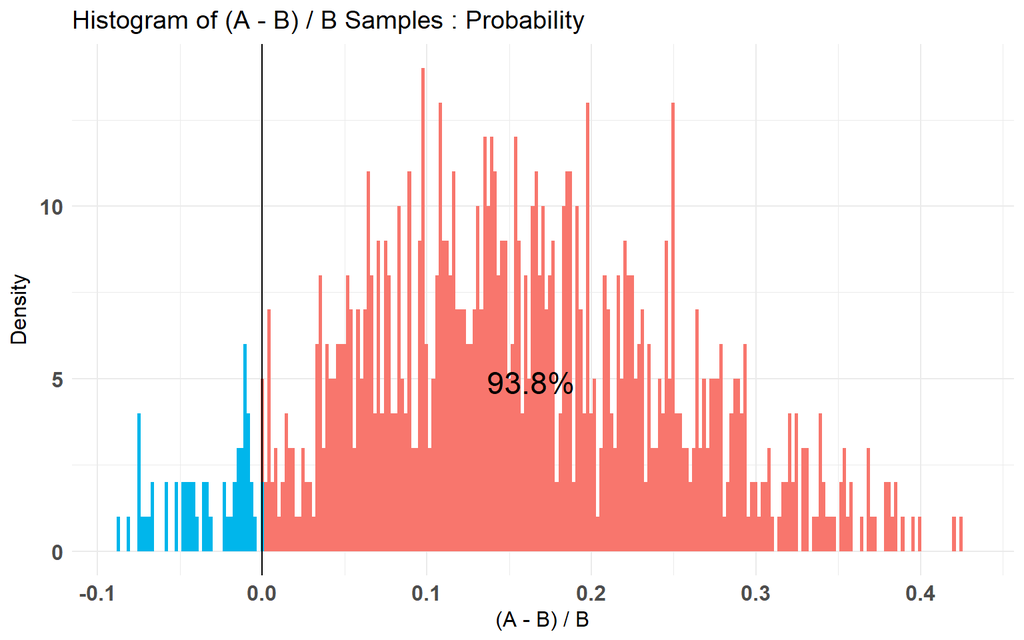

```r
plot(ab1)
```

Although it is very seductive, using Bayesian inference to combine subjective and objective likelihoods has clear risks and makes some statisticians nervous. There is no universal best strategy to A/B testing but being aware of both Frequentist and Bayesian inference paradigms is a useful starting point.

# Initial MS Rave Feature Analysis

```r
packages("xda", prompt = FALSE)
```

## Get Data

```r
myMSdata <- read_csv("~/GitHub/Valorem/ClientProjects/MS_O365/data/CaseNotesSearchABHistorical_Dec13.csv", progress = FALSE)
glimpse(myMSdata)
```

```
## Observations: 377,201
## Variables: 7
## $ RequestID      <chr> "8ff84ae4-0c7b-4916-8e0d-1c5cf08bb1b7", "afbfe3...
## $ IsResolved     <chr> NA, NA, NA, NA, NA, NA, NA, NA, NA, NA, NA, NA,...
## $ PartnerId      <chr> "6aff7e10-a5a2-44fe-840e-aa3d1ff77a0a", "19d915...
## $ ReScenario     <chr> "Not ReScenario", "Not ReScenario", "Not ReScen...
## $ TTR            <int> 3, 3, 3, 3, 3, 3, 3, 3, 3, 3, 3, 3, 3, 3, 3, 3,...
## $ CreateDateTime <chr> "12/13/2017 23:04", "12/13/2017 21:06", "12/13/...
## $ Roles          <chr> "Agent", "Agent", "EscalationEngineer,Agent,Par...
```

```r
myMSdata <- myMSdata %>% mutate(CreateTime2 = mdy_hm(CreateDateTime)) %>% select(-CreateDateTime) %>%
     tidyr::drop_na(PartnerId) %>% glimpse()
```

```
## Observations: 377,193
## Variables: 7
## $ RequestID   <chr> "8ff84ae4-0c7b-4916-8e0d-1c5cf08bb1b7", "afbfe3a9-...
## $ IsResolved  <chr> NA, NA, NA, NA, NA, NA, NA, NA, NA, NA, NA, NA, NA...
## $ PartnerId   <chr> "6aff7e10-a5a2-44fe-840e-aa3d1ff77a0a", "19d9151e-...
## $ ReScenario  <chr> "Not ReScenario", "Not ReScenario", "Not ReScenari...
## $ TTR         <int> 3, 3, 3, 3, 3, 3, 3, 3, 3, 3, 3, 3, 3, 3, 3, 3, 3,...
## $ Roles       <chr> "Agent", "Agent", "EscalationEngineer,Agent,Partne...
## $ CreateTime2 <dttm> 2017-12-13 23:04:00, 2017-12-13 21:06:00, 2017-12...
```

Convert most `character` to `factor`.

```r
names(myMSdata)
```

```
## [1] "RequestID"   "IsResolved"  "PartnerId"   "ReScenario"  "TTR"
## [6] "Roles"       "CreateTime2"
```

```r
myMSdata[, c(4,6)] <- myMSdata[,c(4,6)] %>% mutate_if(is.character, as.factor)
glimpse(myMSdata)
```

```
## Observations: 377,193
## Variables: 7
## $ RequestID   <chr> "8ff84ae4-0c7b-4916-8e0d-1c5cf08bb1b7", "afbfe3a9-...
## $ IsResolved  <chr> NA, NA, NA, NA, NA, NA, NA, NA, NA, NA, NA, NA, NA...
## $ PartnerId   <chr> "6aff7e10-a5a2-44fe-840e-aa3d1ff77a0a", "19d9151e-...
## $ ReScenario  <fctr> Not ReScenario, Not ReScenario, Not ReScenario, N...
## $ TTR         <int> 3, 3, 3, 3, 3, 3, 3, 3, 3, 3, 3, 3, 3, 3, 3, 3, 3,...
## $ Roles       <fctr> Agent, Agent, EscalationEngineer,Agent,PartnerAdm...
## $ CreateTime2 <dttm> 2017-12-13 23:04:00, 2017-12-13 21:06:00, 2017-12...
```

```r
numSummary(myMSdata)
```

```
##          n mean   sd    max    min  range nunique nzeros  iqr lowerbound
## TTR 377193 2380 5365 210324 -25736 236060   19485    260 2783      -4154
##     upperbound noutlier kurtosis skewness mode miss miss% 1% 5% 25% 50%
## TTR       6978    45422      131     7.67   10    0     0  2  5  20  88
##      75%   95%   99%
## TTR 2803 10484 21393
```

```r
charSummary(myMSdata)
```

```
##                 n   miss miss% unique
## RequestID  377193      0   0.0 377193
## IsResolved 187026 190167  50.4      3
## PartnerId  377193      0   0.0   3282
## ReScenario 377193      0   0.0     11
## Roles      377193      0   0.0     31
##                                                                                                                                                                                                            top5levels:count
## RequestID            00001e68-c146-4556-89fb-e3e0f546446e:1, 00001eb7-3d3e-464a-8eb5-289336b1ffb1:1, 000027b9-d53f-4610-80dd-372ceb319293:1, 0000343b-5402-4eec-a55d-7537cb6d0e96:1, 00005ac1-a786-42cc-a293-aad26019e929:1
## IsResolved                                                                                                                                                                                          TRUE:177278, FALSE:9748
## PartnerId  64c5d37a-33ef-45d4-a38c-a5f3ec72ac6e:867, 522a0315-735e-4d74-8ddc-decb0df5b4aa:676, 380a0f03-f847-4c7e-926f-18dc1f6f6c97:674, d4bfbe9a-1eff-404c-b961-8e93e1190dec:657, a4c71253-9a92-49bd-be5e-29e6d72dc3ea:655
## ReScenario                                                                                              Not ReScenario:327748, Idle Re-route Engineering:33033, Customer Reopen:6020, Repeat Caller:2660, Agent Reopen:2524
## Roles                                                                                       Agent:227623, #N/A:53458, Agent,PartnerAdmin,EscalationEngineer:32040, Agent,EscalationEngineer:13834, FirstRelease,Agent:13435
```

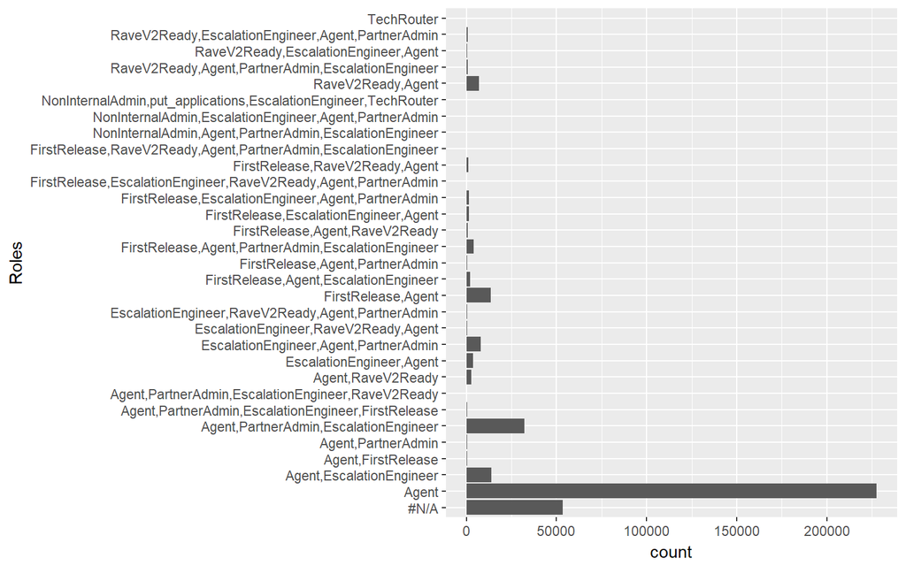

```r
ggplot(myMSdata, aes(x=Roles)) + geom_bar() + coord_flip()
```

```r
table(myMSdata$Roles)
```

```
##
##                                                            #N/A
##                                                           53458
##                                                           Agent
##                                                          227623
##                                        Agent,EscalationEngineer
##                                                           13834
##                                              Agent,FirstRelease
##                                                             528
##                                              Agent,PartnerAdmin
##                                                             472
##                           Agent,PartnerAdmin,EscalationEngineer
##                                                           32040
##              Agent,PartnerAdmin,EscalationEngineer,FirstRelease
##                                                             461
##               Agent,PartnerAdmin,EscalationEngineer,RaveV2Ready
##                                                              90
##                                               Agent,RaveV2Ready
##                                                            2791
##                                        EscalationEngineer,Agent
##                                                            3785
##                           EscalationEngineer,Agent,PartnerAdmin
##                                                            7871
##                            EscalationEngineer,RaveV2Ready,Agent
##                                                             451
##               EscalationEngineer,RaveV2Ready,Agent,PartnerAdmin
##                                                             306
##                                              FirstRelease,Agent
##                                                           13435
##                           FirstRelease,Agent,EscalationEngineer
##                                                            1945
##                                 FirstRelease,Agent,PartnerAdmin
##                                                             360
##              FirstRelease,Agent,PartnerAdmin,EscalationEngineer
##                                                            3966
##                                  FirstRelease,Agent,RaveV2Ready
##                                                             928
##                           FirstRelease,EscalationEngineer,Agent
##                                                            1531
##              FirstRelease,EscalationEngineer,Agent,PartnerAdmin
```

[output cut: 8 more lines]

```
##                                                               1
##          NonInternalAdmin,EscalationEngineer,Agent,PartnerAdmin
##                                                              23
## NonInternalAdmin,put_applications,EscalationEngineer,TechRouter
##                                                               2
##                                               RaveV2Ready,Agent
##                                                            6851
##               RaveV2Ready,Agent,PartnerAdmin,EscalationEngineer
##                                                             633
##                            RaveV2Ready,EscalationEngineer,Agent
##                                                             308
##               RaveV2Ready,EscalationEngineer,Agent,PartnerAdmin
##                                                             805
##                                                      TechRouter
##                                                              29
```

[figure not shown]

```r
options(scipen = 999)
myGrpTTR <- group_by(myMSdata, TTR)
myPlot1data <- summarize(myGrpTTR, TTRcnt = n())

cntNeg <- nrow(filter(myPlot1data, TTR < 1))
cntBIG <- nrow(filter(myPlot1data, TTR > 20160))#2 weeks

myBreaks_day <- c(seq(from=0, to=max(myMSdata$TTR), by=1440), Inf)#
myPlot1data$TTR_day <- cut(myPlot1data$TTR, breaks = myBreaks_day, dig.lab = 8)
ggplot(myPlot1data, aes(x=TTR_day, y=TTRcnt)) + geom_bar(stat = "identity") + coord_flip()
```

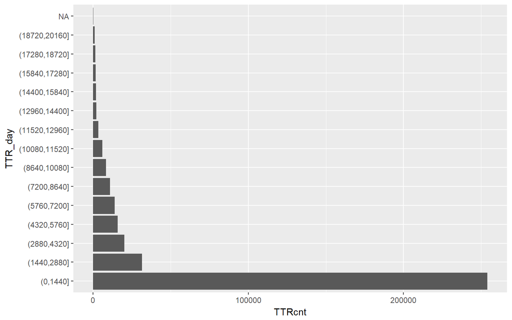

```r
ggplot(filter(myPlot1data, TTR<20000), aes(x=TTR_day, y=TTRcnt)) + geom_bar(stat = "identity") + coord_flip()
```

```r
# myBreaks_week <- c(-Inf, seq(from=0, to=max(myMSdata$TTR), by=10080), Inf)#10080 min/week
# myPlot1data$TTR_week <- cut(myPlot1data$TTR, breaks = myBreaks_week, dig.lab = 8)
# ggplot(myPlot1data, aes(x=TTR_week, y=TTRcnt)) + geom_bar(stat = "identity") + coord_flip()
#
#
# myBreaks_2Week <- c(-Inf, seq(from=0, to=max(myMSdata$TTR), by = 20160), Inf)
# myPlot1data$TTR_2week <- cut(myPlot1data$TTR, breaks = myBreaks_2Week, dig.lab = 8)
# ggplot(myPlot1data, aes(x=TTR_2week, y=TTRcnt)) + geom_bar(stat = "identity") + coord_flip()
#
# myBreaks_4Week <- c(-Inf, seq(from=0, to=max(myMSdata$TTR), by = 40320), Inf)
# myPlot1data$TTR_4week <- cut(myPlot1data$TTR, breaks = myBreaks_4Week, dig.lab = 8)
# ggplot(myPlot1data, aes(x=TTR_4week, y=TTRcnt)) + geom_bar(stat = "identity") + coord_flip()
```

```r
#86,400 minutes in 60 days
cat("The number of records with a TTR longer than 60 days is", nrow(filter(myPlot1data, TTR > 86400)))
```

[output not shown]

Remove records where TTR < 0.

```r
myMSdata <- filter(myMSdata, TTR > 0)
```

In the first exercise, `ReScenario` is filtered. Also, remove `isResolved` records = NA

```r
levels(myMSdata$ReScenario)
```

```
##  [1] "Agent Reopen"                     "Customer Reopen"
##  [3] "EscAlch - CMQ"                    "EscAlch - ICW"
##  [5] "EscAlch - IOS"                    "EscAlch - SL"
##  [7] "Idle Re-route Engineering"        "Language Reroute"
##  [9] "Not ReScenario"                   "Repeat Caller"
## [11] "Reroute (Between MS Departments)"
```

```r
myMSdata_ReOpen <- filter(myMSdata, ReScenario == "Customer Reopen")
myMSdata_ReOpen <- mutate(myMSdata_ReOpen, IsResolved = parse_logical(IsResolved))
myMSdata_ReOpen <-  filter(myMSdata_ReOpen, !is.na(IsResolved))
table(myMSdata_ReOpen$IsResolved)
```

```
##
## FALSE  TRUE
##   195  2599
```

## Prepare DF for bayesAB

```r
myMSdata_ReOpen <- myMSdata_ReOpen %>% mutate(IsResolvedNum = ifelse(myMSdata_ReOpen$IsResolved == TRUE, 1,0))
control <- myMSdata_ReOpen$IsResolvedNum
mu_control <- mean(control)
var_control <- var(control)

myBetas <- Beta_Parameters(mu_control, var_control)#returning negative values - need estimates of mean and sd
plotBeta(myBetas$alpha, myBetas$beta)

#experiment
plotBeta(200, 100)#lnot good
myBetas <- Beta_Parameters(.93, .01)#returning negative values - need estimates of mean and sd
plotBeta(myBetas$alpha, myBetas$beta)

ab1 <- bayesTest(control, B_binom, priors = c(alpha = 5.12, beta = .386), n_samples = 2000, distribution = 'bernoulli')
```

# Side Analysis

```r
library(stringr)
myMSdata2 <- myMSdata %>% mutate(Roles_match_Agent = str_detect(Roles, "Agent"))
table(myMSdata2$Roles_match_Agent)
```

```
##
##  FALSE   TRUE
##  53466 323440
```

```r
myMSdata2 <- myMSdata2 %>% mutate(Roles_match_Rave2 = str_detect(Roles, "RaveV2"))
table(myMSdata2$Roles_match_Rave2)
```

```
##
##  FALSE   TRUE
## 362648  14258
```

```r
myMSdata2 <- myMSdata2 %>% mutate(Roles_match_FirstRelease = str_detect(Roles, "FirstRelease"))
table(myMSdata2$Roles_match_FirstRelease)
```

```
##
##  FALSE   TRUE
## 351109  25797
```

```r
prop.table(table(myMSdata2$Roles_match_Agent))
```

```
##
## FALSE  TRUE
## 0.142 0.858
```

```r
prop.table(table(myMSdata2$Roles_match_Rave2))
```

```
##
##  FALSE   TRUE
## 0.9622 0.0378
```

```r
prop.table(table(myMSdata2$Roles_match_FirstRelease))
```

```
##
##  FALSE   TRUE
## 0.9316 0.0684
```

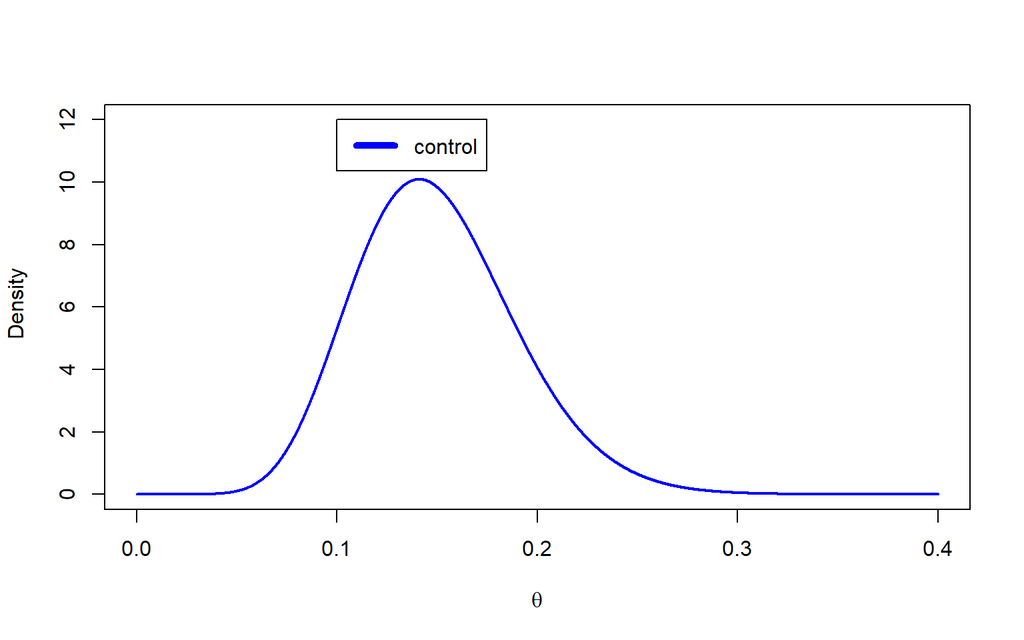

```r
#Generate alpha and beta for beta distributions priors
a <- Beta_Parameters(0.15,0.0016)#0.04^2
# b <- Beta_Parameters(0.16,0.0016)
# c <- Beta_Parameters(0.17,0.0016)

#Plot prior beta distibutions for the three ads (A,B, and C)
x = seq(0, 0.4, length = 10000)
y = dbeta(x, a$alpha, a$beta)
# y1 = dbeta(x, b$alpha, b$beta)
# y2 = dbeta(x, c$alpha, c$beta)
{plot(x, y, type = "l", col = "blue", ylim = c(0, 12),xlim = c(0, .40),lwd = 2, ylab =' Density', xlab = expression(theta))
# lines(x, y1, col = "orange", lwd = 2)
# lines(x, y2, col = "black", lwd = 2)
#legend(0.1, 12, legend = c("A", "B", "C"), col = c("blue","orange","black"), lwd = 5, cex = 1, horiz = TRUE)
legend(0.1, 12, legend = c("control"), col = c("blue"), lwd = 5, cex = 1, horiz = TRUE)
}
```